# Plastic Waste Project

**Research Question: Is plastic waste associated with air quality across countries?**

The data comes from **Break Free From Plastic** global brand audits conducted in 2019 and 2020, where volunteers physically collected and recorded plastic pieces by type and company label. The dataset was put together by Sarah Sauve and covers dozens of countries worldwide. You can find it [here](https://github.com/sarahsauve/TidyTuesdays/blob/master/BFFPDashboard/BlogPost.md).

We combined this data with:

- **Country Capitals GPS data** — to map each country’s coordinates
- **Air Quality API (API Ninjas)** — to pull AQI scores by capital city

The observational unit is one brand audited in one country in one year. Key variables include plastic type counts, grand total, number of volunteers, and average AQI score per country.

**Why does this matter?** Countries with high plastic pollution may face compounding environmental pressures. Understanding whether plastic waste and air quality are linked can help policymakers prioritize environmental interventions.

**Key Findings:**

- The **Philippines** has the highest plastic waste of any country in our dataset
- There is **no strong linear relationship** between plastic waste and air quality across countries

[interactive chart not shown]

Circle size = total plastic waste. Color = average AQI (green = good, red = unhealthy). Click a country for details.

| Countries in Dataset | 69 |
| --- | --- |
| Total Plastic Pieces | 1,204,956 |
| Countries with AQI Data | 58 |
| Years Covered | 2019 – 2020 |

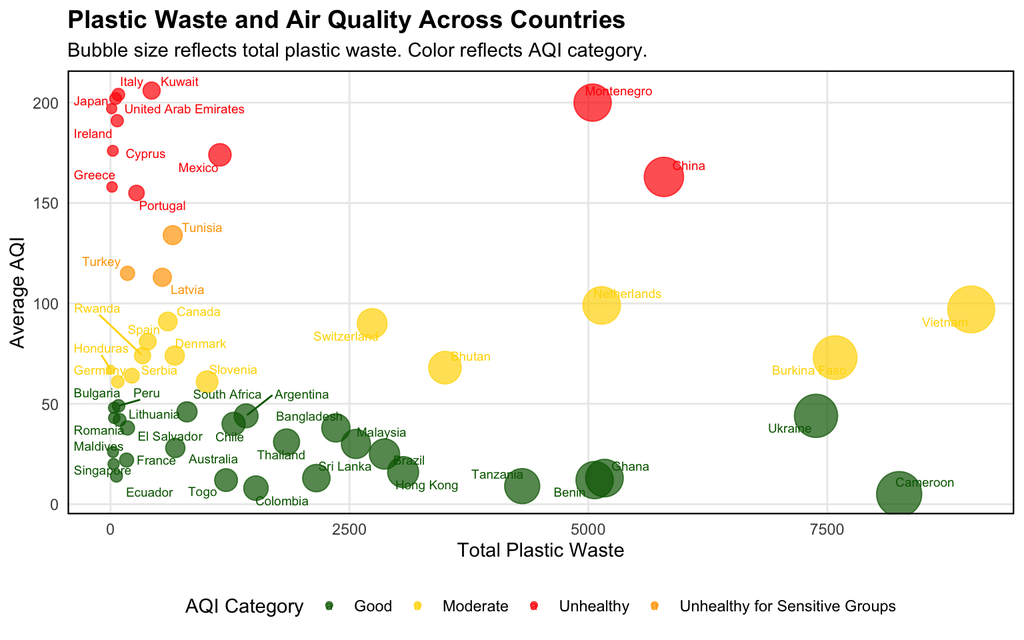

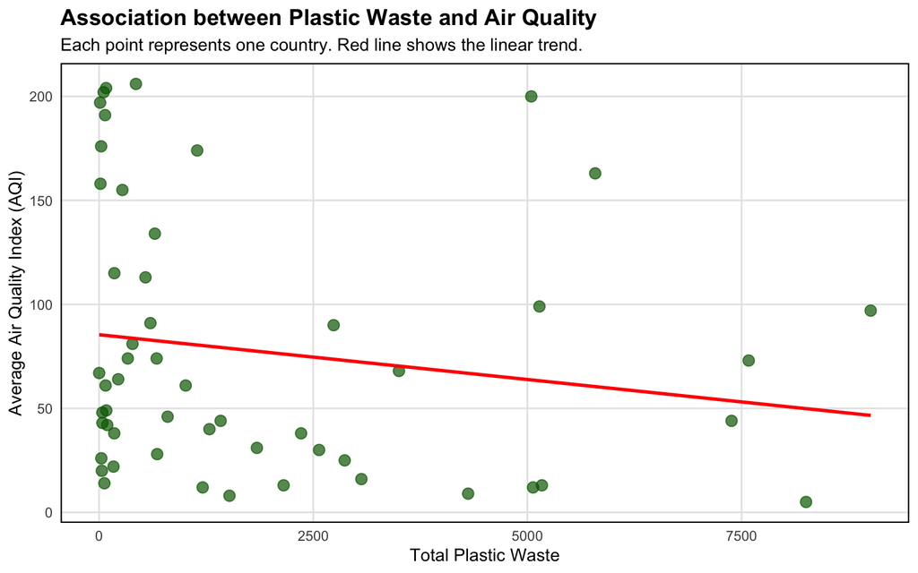

**Top 10 Countries**

Top 10 Countries by Plastic Waste

With corresponding average AQI

| Country | Total Plastic | Avg AQI |
| --- | --- | --- |
| Philippines | 58,094 | 41.0 |
| Nigeria | 21,834 | 71.0 |
| Kenya | 14,522 | 24.0 |
| India | 14,478 | 155.0 |
| Indonesia | 12,843 | 26.0 |
| Vietnam | 9,007 | 97.0 |
| Cameroon | 8,253 | 5.0 |
| Burkina Faso | 7,583 | 73.0 |
| Ukraine | 7,383 | 44.0 |
| China | 5,791 | 163.0 |

**AQI by Plastic Level**

Air Quality by Plastic Waste Level

Countries grouped into quartiles by total plastic waste

| Plastic Waste Group | Number of Countries | Average AQI | Minimum AQI | Maximum AQI |
| --- | --- | --- | --- | --- |
| Low (Q1) | 14 | 104.00 | 14 | 204 |
| Medium-Low (Q2) | 13 | 93.00 | 22 | 206 |
| Medium-High (Q3) | 13 | 47.31 | 8 | 174 |
| High (Q4) | 13 | 63.38 | 5 | 200 |

Note: Higher AQI indicates worse air quality.Countries filtered to remove outliers.

**Model Results**

Linear Regression Results

Predicting Average AQI from Total Plastic Waste

| Term | Coefficient Estimate | Coefficient Std. Error | Test t | Test p-value |
| --- | --- | --- | --- | --- |
| Intercept | 79.584 | 8.962 | 8.880 | 0.0000 |
| Total Plastic | −0.001 | 0.001 | −0.911 | 0.3664 |

R² = 0.0146 | Adj. R² = -0.003 | F = 0.829 | p = 0.3664

Philippines — Key Stats

| Country | Total Plastic Waste | Average AQI |
| --- | --- | --- |
| Philippines | 58,094 | 41.0 |

Source: BFFP brand audit data (2019–2020) + API Ninjas AQI

*An animated look at how the Philippines’ birth rate has declined and what it means for future plastic waste.*

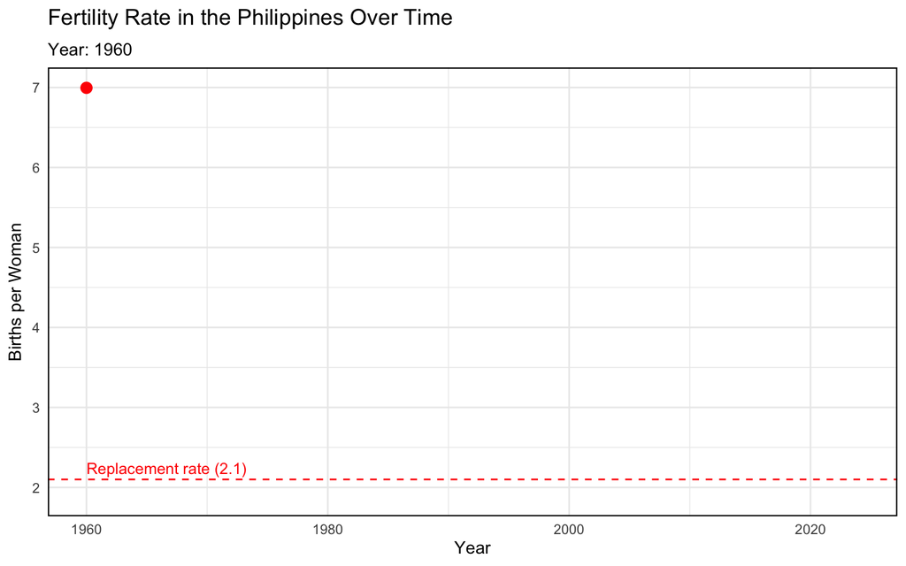